[figure not shown]

### A good test of a model is its versatility in explaining multiple datasets generated in diverse experimental settings.

A good test of a model is its versatility in explaining multiple datasets generated in diverse experimental settings.

–

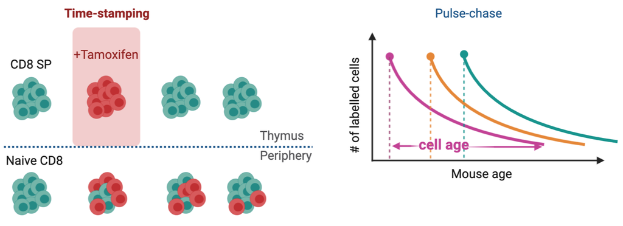

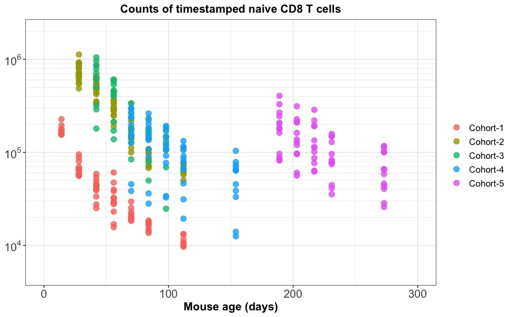

–

### Need for Hierrarchical modelling:

- **Pooling information among cohorts** while fitting models.

–

- Within cohorts **repeat sampling on individual mice** — Pooling information among mice.

??? - The slope of ‘decay curve’ informs on the dependence of **net loss rate** (death - division) on cell-age.

- The difference in in slopes of each cohort informs on effects of host age.

Comparison of the ASM hierarchical models

|  | ΔLooIC | Akaike weight % |
| --- | --- | --- |
| N0: mice and λ: cohort | 0.00 | 100 |
| N0: mice and λ: mice | 73.06 | 0 |
| N0: cohort and λ: mice | 313.94 | 0 |
| N0: mice | 316.71 | 0 |

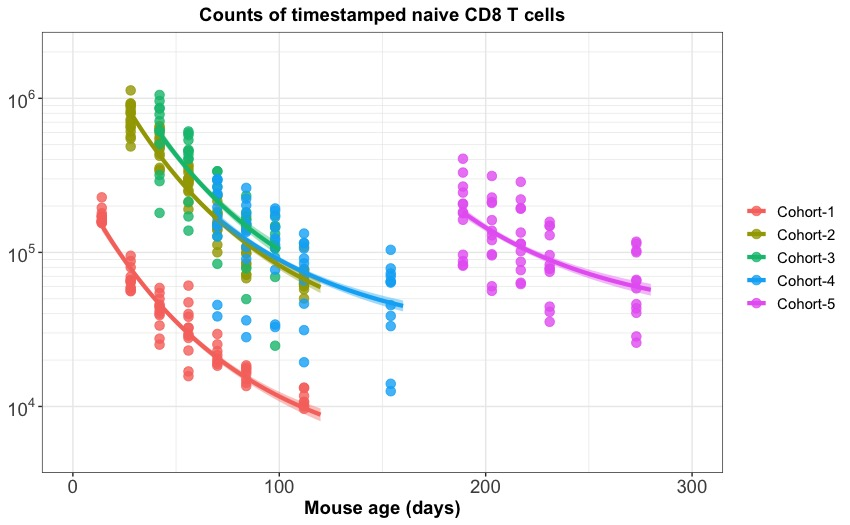

### Summary from the timestamp data

- The hierarchical model reveals cohort-specific effects on the net loss rate $\small \lambda$ of naive T cells.
- The major distinction in cohorts is the ** age of the host ** when naive T cells were stamped.  
  ↪ Possible host-age effects in naive T cell maintenance?

–

### Whats Next?

- Adopt density-dependence model to fit on the timestamp data.
- Include host-age dependence in ASM and refit on the ontogeny data.

# Thanks!

[figure not shown]

The models are coded in `Stan` programming language, are compiled using `CMDSTAN` interface and analysed in R using `Rstan` package.

Slides created in `html` using [remark.js](https://remarkjs.com) and R packages [**knitr**](http://yihui.name/knitr) and [**xaringan**](https://github.com/yihui/xaringan).